# Elegant ggplot2 (Arranging Plots), with tidyplots equivalents

Source: `elegant_ggplot2_vs_tidyplot_9.qmd`

Author

Steve Rozen (sr110@duke.edu, steverozen@pm.me)

Published

2026-06-28 20:07

## About this handout

This follows the *Arranging plots* chapter of Hadley Wickham, Danielle Navarro, and Thomas Lin Pedersen’s [*ggplot2: Elegant Graphics for Data Analysis* (3rd edition)](https://ggplot2-book.org/arranging-plots.html). For each step we keep the original **ggplot2 + patchwork** code, then show the **tidyplots** equivalent.

The headline is different from the other handouts in this series. The earlier chapters were about drawing one plot, where ggplot2 and tidyplots are two competing grammars. **Arranging several finished plots into one figure is not part of either grammar.** It is the job of a third package, [patchwork](https://patchwork.data-imaginist.com), and the good news is:

- **patchwork operates on tidyplots objects unchanged.** A `tidyplot()` returns an object that is still a ggplot under the hood, so `+`, `/`, `|`, `plot_layout()`, `plot_annotation()`, and `inset_element()` all work on tidyplots exactly as they do on ggplots.
- So the translation in this chapter is almost a no-op: build each panel with whichever grammar you like, then compose them with the **same** patchwork code. The only thing that changes is how each individual panel is drawn.

Two things are worth naming up front because they are tidyplots-specific:

1. **tidyplots has no arranging grammar of its own.** Its only multi-panel verb is `split_plot()`, which splits *one* plot into facet-like panels by a grouping variable. It does **not** compose distinct, separately-built plots. For that, you reach for patchwork.
2. **Always build tidyplots panels with `width = NA, height = NA`.** tidyplots otherwise locks every panel to a fixed 50 x 50 mm square, which fights patchwork’s alignment and leaves panels different sizes. `width = NA, height = NA` lets each panel flex so patchwork can align and size them like ggplots.

## Setup

```r
library(ggplot2)        # the book's package
library(tidyplots)      # the package we translate each panel into
library(patchwork)      # the arranging package (works on BOTH)
library(dplyr)          # for the one mutate() precompute
data("mpg", package = "ggplot2")          # 234 car models
```

## The four base plots

The chapter builds four example plots and then arranges them every which way. Here they are in both grammars. Notice that the *arranging* code later is identical; only these four definitions differ.

### ggplot2

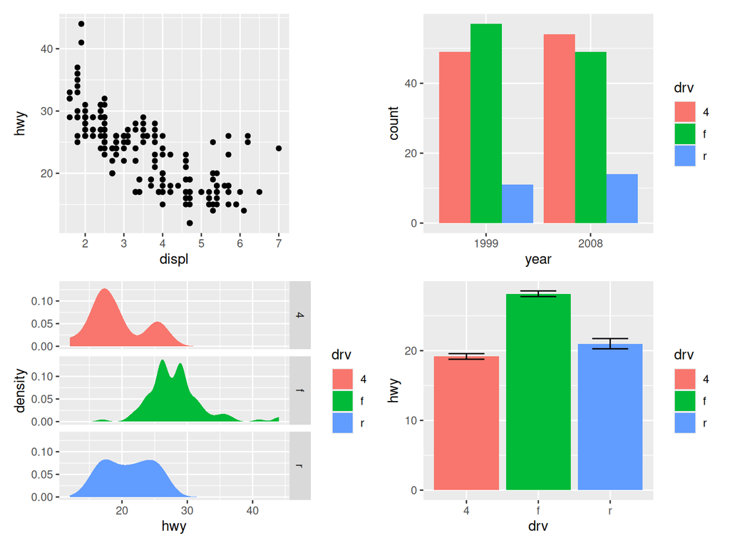

```r
p1 <- ggplot(mpg) +
  geom_point(aes(x = displ, y = hwy))

p2 <- ggplot(mpg) +
  geom_bar(aes(x = as.character(year), fill = drv), position = "dodge") +
  labs(x = "year")

p3 <- ggplot(mpg) +
  geom_density(aes(x = hwy, fill = drv), colour = NA) +
  facet_grid(rows = vars(drv))

p4 <- ggplot(mpg) +
  stat_summary(aes(x = drv, y = hwy, fill = drv), geom = "col", fun.data = mean_se) +
  stat_summary(aes(x = drv, y = hwy), geom = "errorbar", fun.data = mean_se, width = 0.5)

p1 + p2 + p3 + p4
```

### tidyplots

The same four panels as tidyplots. Each carries `width = NA, height = NA` so patchwork can align them.

- `p2` (dodged count bar) becomes `add_count_bar()`. The `color = drv` mapping set in `tidyplot()` dodges the bars automatically.
- `p3` (filled density) has **no native tidyplots verb**, so it uses the escape hatch `add(ggplot2::geom_density())` plus `add(ggplot2::facet_grid())`.
- `p4` (mean +/- SEM column) becomes `add_mean_bar()` then `add_sem_errorbar()`, two verbs instead of two `stat_summary()` layers.

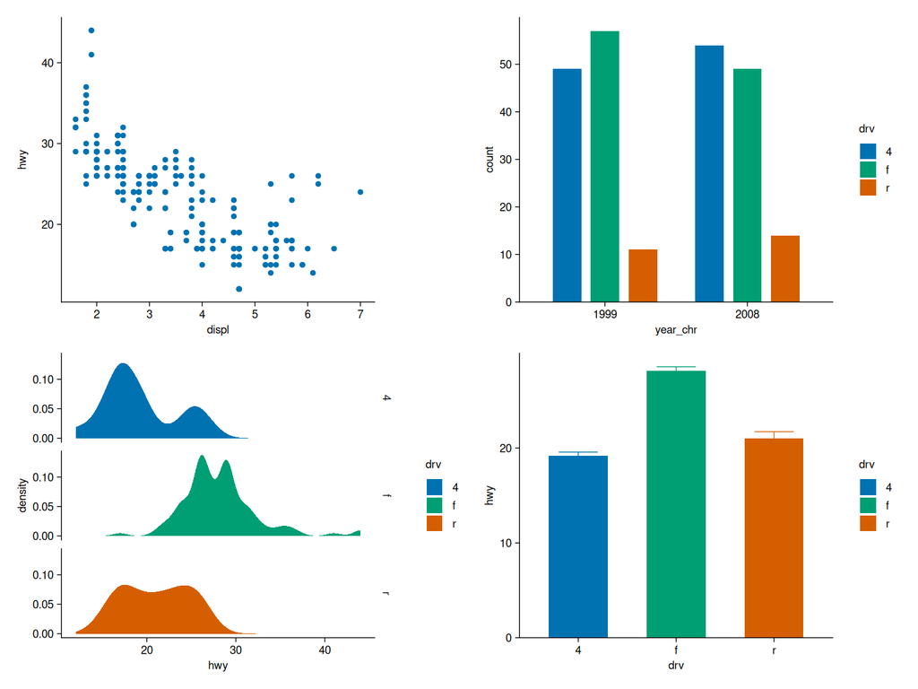

```r
mpg2 <- mpg |> mutate(year_chr = as.character(year))   # tidyplot() wants a bare column

t1 <- mpg |> tidyplot(x = displ, y = hwy, width = NA, height = NA) |>
  add_data_points()

t2 <- mpg2 |> tidyplot(x = year_chr, color = drv, width = NA, height = NA) |>
  add_count_bar()

t3 <- mpg |> tidyplot(x = hwy, color = drv, width = NA, height = NA) |>
  add(ggplot2::geom_density(ggplot2::aes(fill = drv), colour = NA)) |>
  add(ggplot2::facet_grid(rows = vars(drv)))

t4 <- mpg |> tidyplot(x = drv, y = hwy, color = drv, width = NA, height = NA) |>
  add_mean_bar() |>
  add_sem_errorbar()

t1 + t2 + t3 + t4     # <- identical patchwork code
```

**NoteWhat to notice**

## 9.1 Laying out plots side by side

`+` places plots next to each other and aligns their plotting regions. With no layout given, patchwork uses `facet_wrap` logic (four plots become a 2 x 2 grid, as above).

### ggplot2

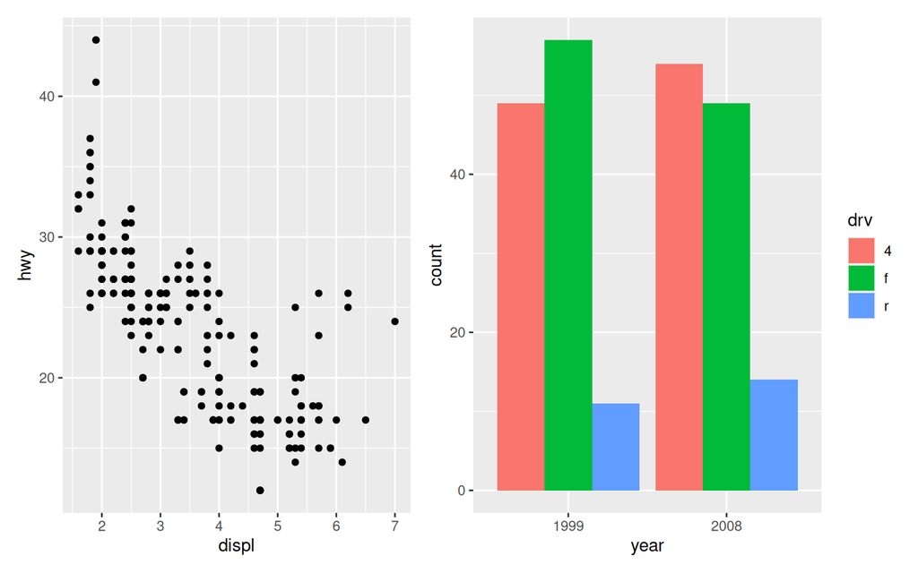

```r
p1 + p2
```

### tidyplots

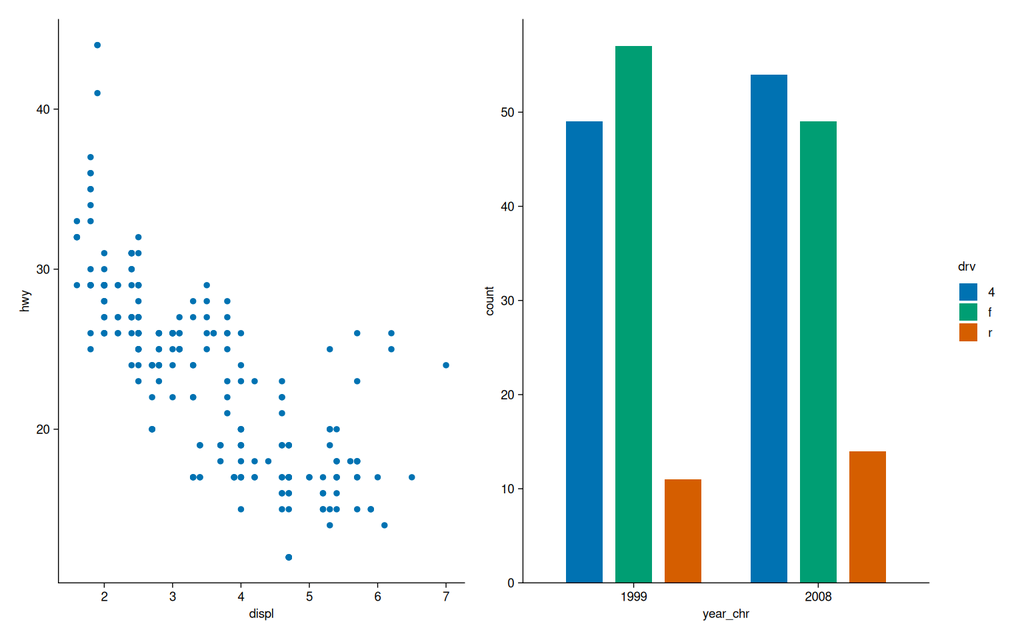

```r
t1 + t2
```

## 9.1.1 Taking control of the layout

Every operator below is pure patchwork, so the ggplot2 and tidyplots versions differ only in which letters (`p` vs `t`) name the panels.

### `plot_layout(ncol = ...)`

**ggplot2**

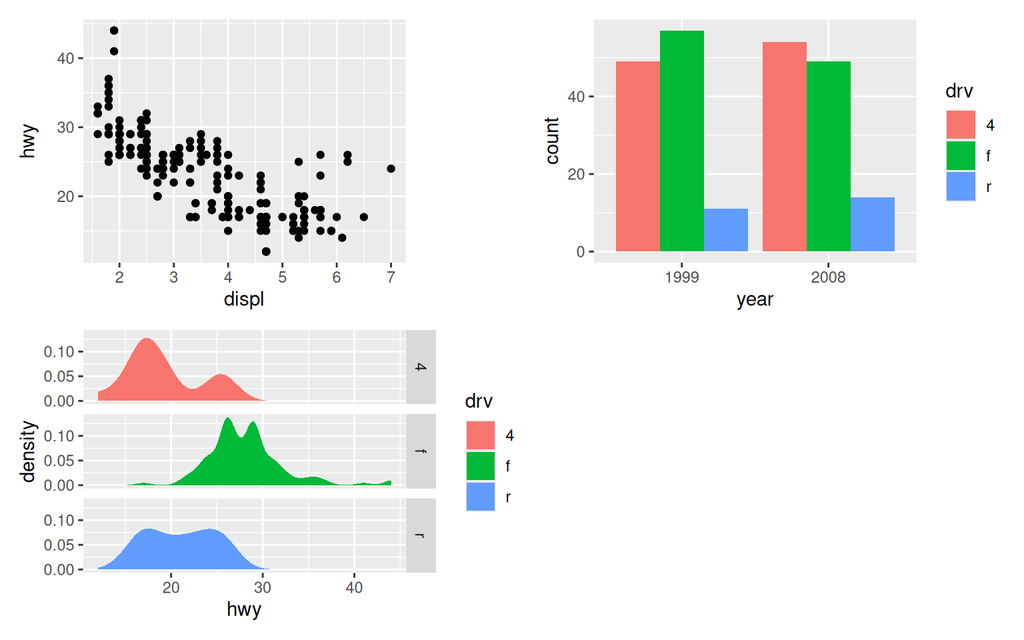

```r
p1 + p2 + p3 + plot_layout(ncol = 2)
```

**tidyplots**

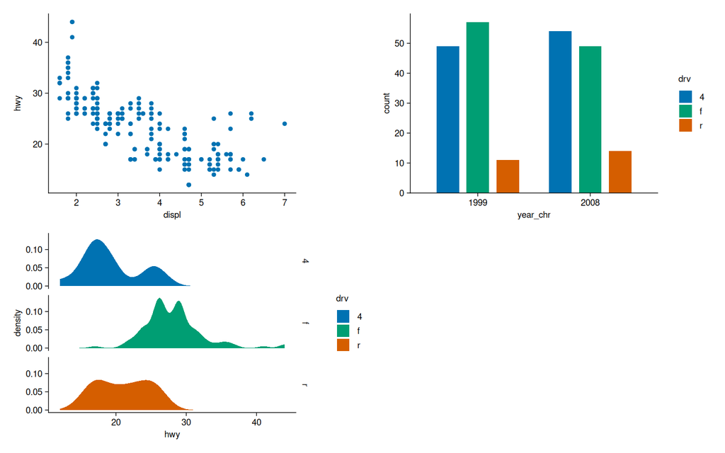

```r
t1 + t2 + t3 + plot_layout(ncol = 2)
```

### Stacking and rows with `/` and `|`

`/` stacks plots vertically, `|` places them in a row, and the two nest to build complex layouts.

**ggplot2**

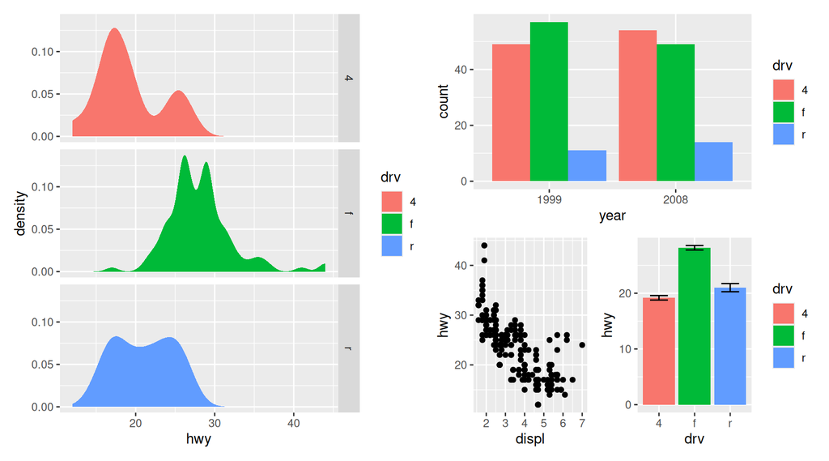

```r
p3 | (p2 / (p1 | p4))
```

**tidyplots**

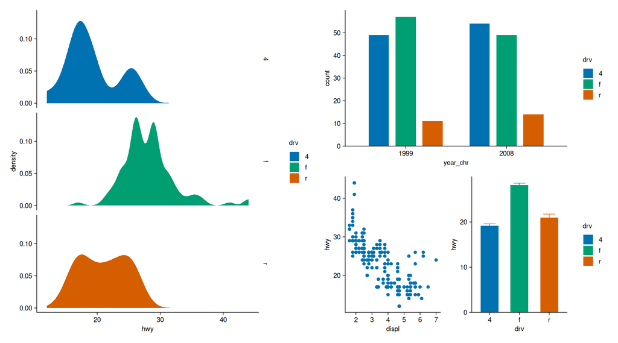

```r
t3 | (t2 / (t1 | t4))
```

### Free-form layouts with a `design` string

A text block names where each plot goes. Letters are filled in plot order, `#` is empty space.

**ggplot2**

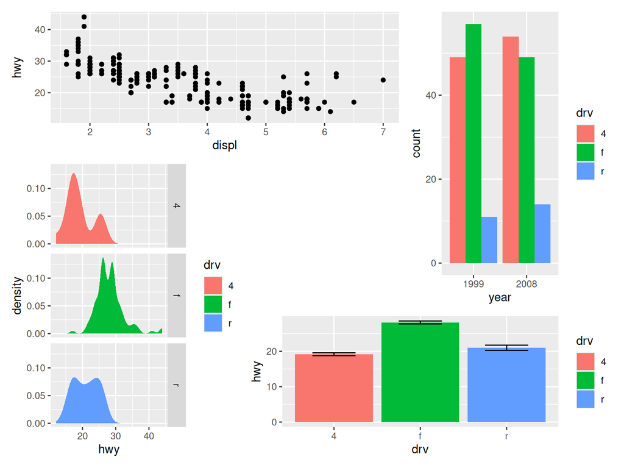

```r
layout <- "
AAB
C#B
CDD
"

p1 + p2 + p3 + p4 + plot_layout(design = layout)
```

**tidyplots**

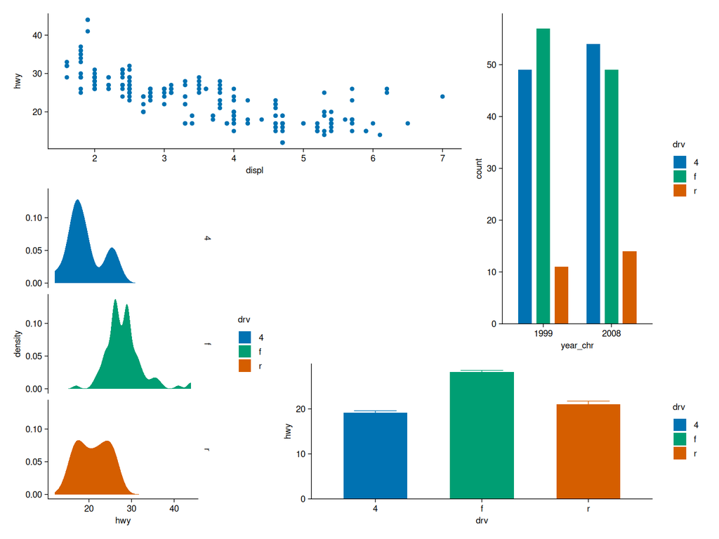

```r
t1 + t2 + t3 + t4 + plot_layout(design = layout)
```

### Collecting guides with `guides = "collect"`

`guides = "collect"` pulls duplicate legends out of the panels and shows one shared legend.

**ggplot2**

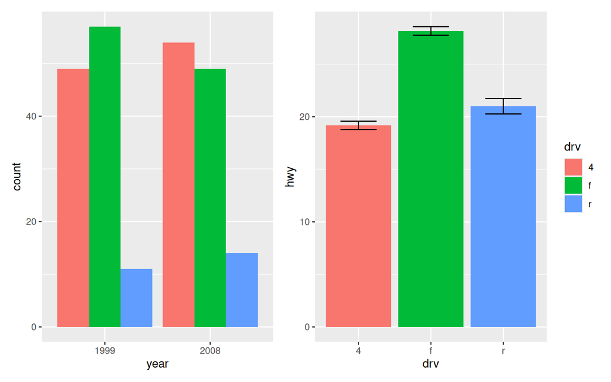

```r
p2 + p4 + plot_layout(ncol = 2, guides = "collect")
```

**tidyplots**

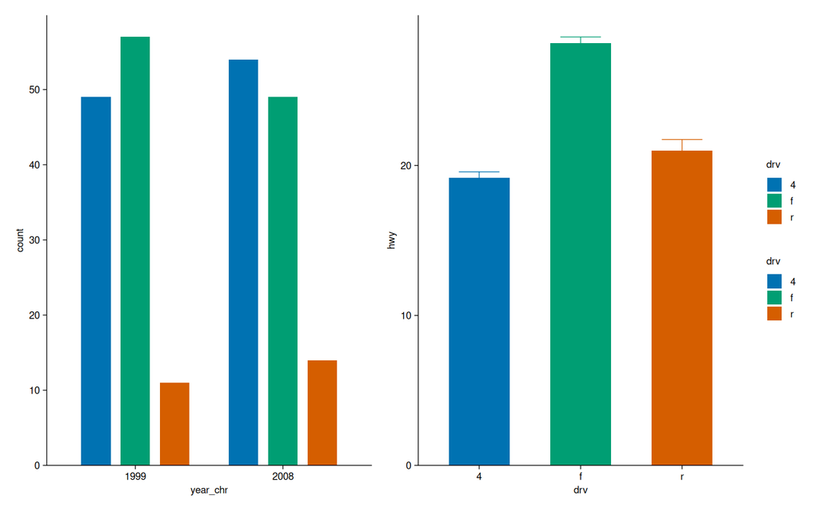

```r
t2 + t4 + plot_layout(ncol = 2, guides = "collect")
```

A `guide_area()` reserves a slot in the layout for the collected legend:

**ggplot2**

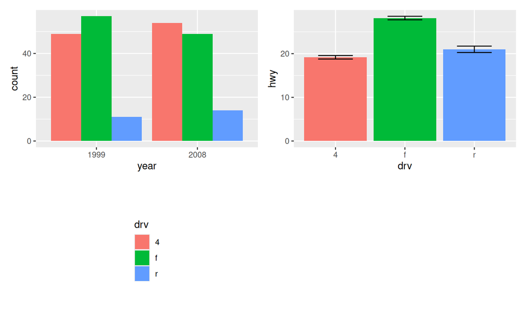

```r
p2 + p4 + guide_area() + plot_layout(ncol = 2, guides = "collect")
```

**tidyplots**

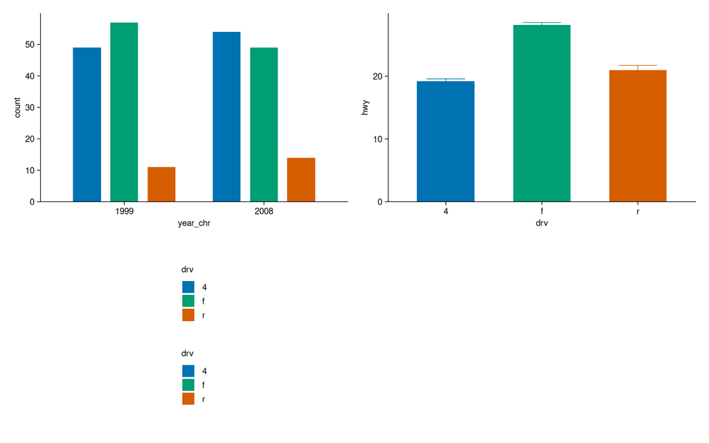

```r
t2 + t4 + guide_area() + plot_layout(ncol = 2, guides = "collect")
```

## 9.1.2 Modifying subplots

A patchwork is still indexable. `[[i]]` reaches in to restyle one panel, and `&` applies a component to *all* panels at once.

### Restyle one panel with `[[ ]]`

**ggplot2**

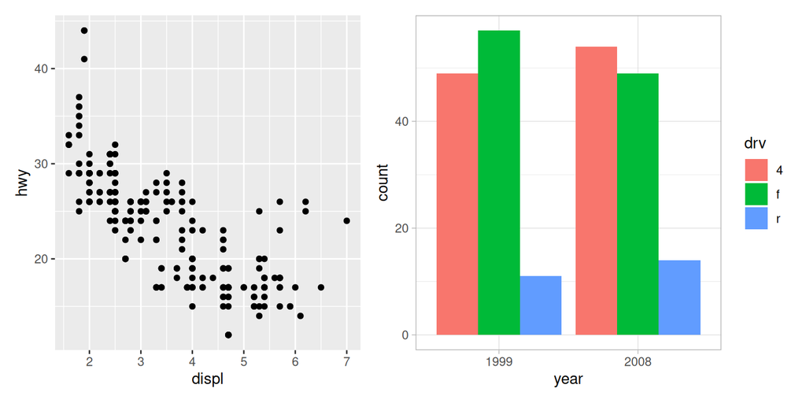

```r
p12 <- p1 + p2
p12[[2]] <- p12[[2]] + theme_light()   # restyle only the second panel
p12
```

**tidyplots**

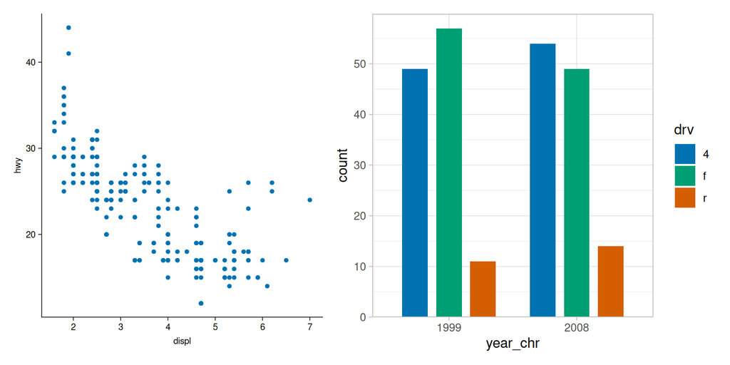

```r
t12 <- t1 + t2
t12[[2]] <- t12[[2]] + theme_light()   # restyle only the second panel
t12
```

### Apply to all panels with `&`

**ggplot2**

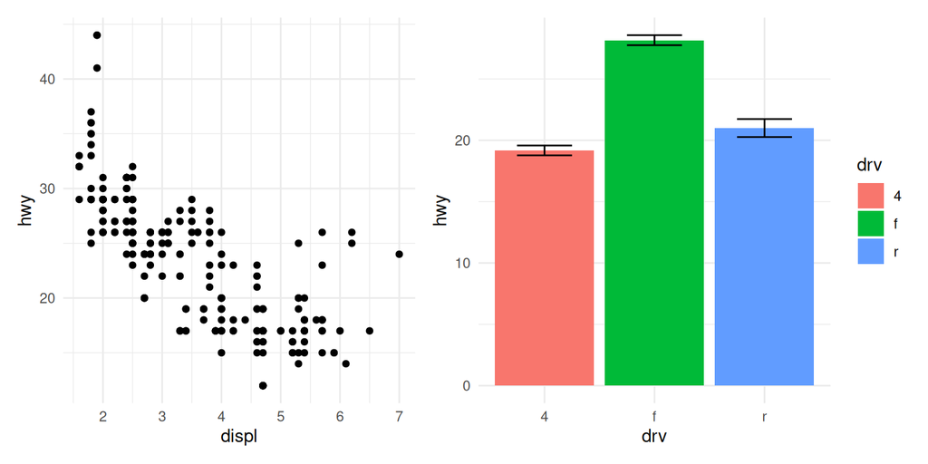

```r
p1 + p4 & theme_minimal()
```

**tidyplots**

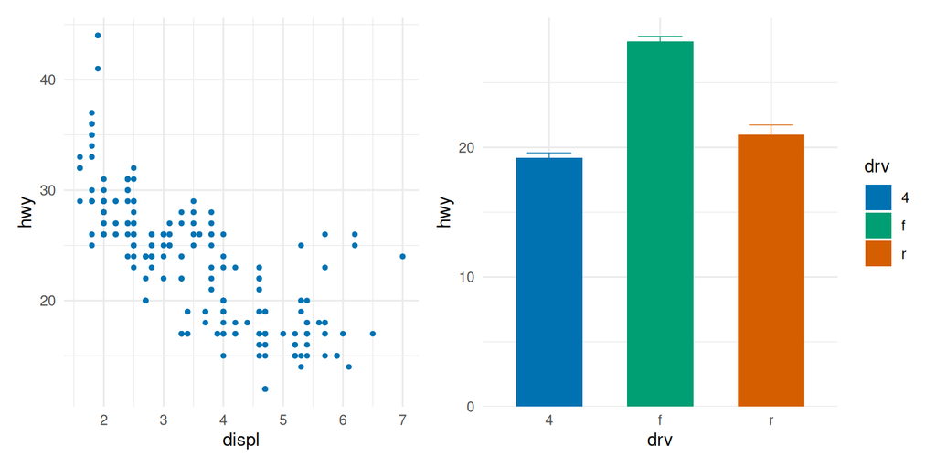

```r
t1 + t4 & theme_minimal()
```

**Warningtidyplots gotcha: `&` overwrites the tidyplots theme**

`&` adds the component to every panel. Adding a complete ggplot2 theme such as `theme_minimal()` therefore **replaces** the tidyplots default styling on each panel (axis lines become a grid, the type face changes). That is fine when you want a uniform look, but if you wanted to keep the tidyplots appearance, use a narrower component (for example `& scale_y_continuous(limits = c(0, 45))`) instead of a whole theme.

A shared scale across panels is the safe use of `&`:

**ggplot2**

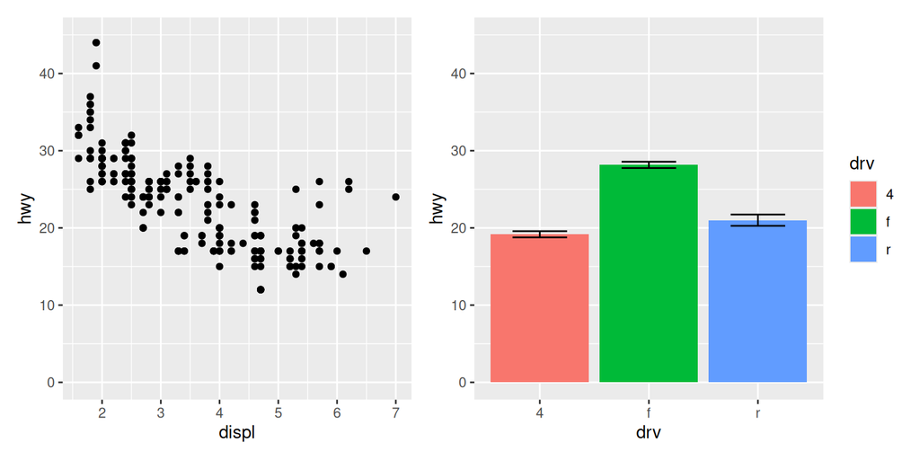

```r
p1 + p4 & scale_y_continuous(limits = c(0, 45))
```

**tidyplots**

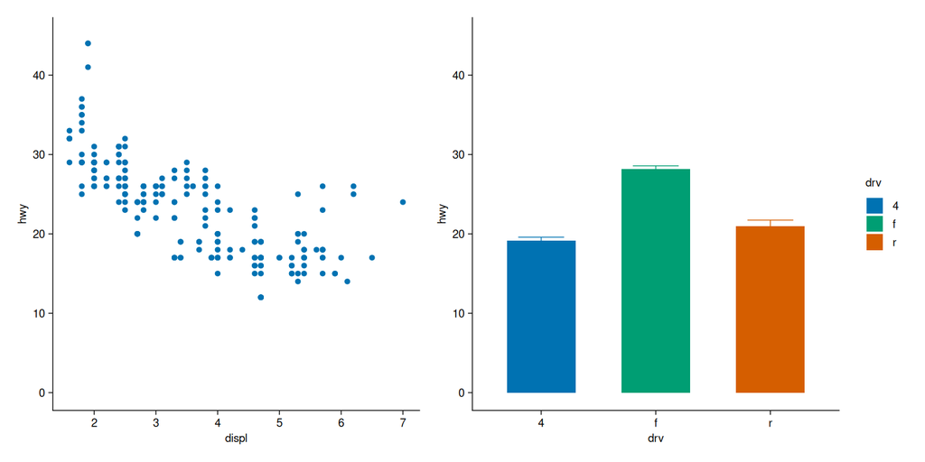

```r
t1 + t4 & scale_y_continuous(limits = c(0, 45))
```

## 9.1.3 Adding annotation

`plot_annotation()` adds a title or caption for the whole assembly, and `tag_levels` auto-labels the panels.

### Title and caption

**ggplot2**

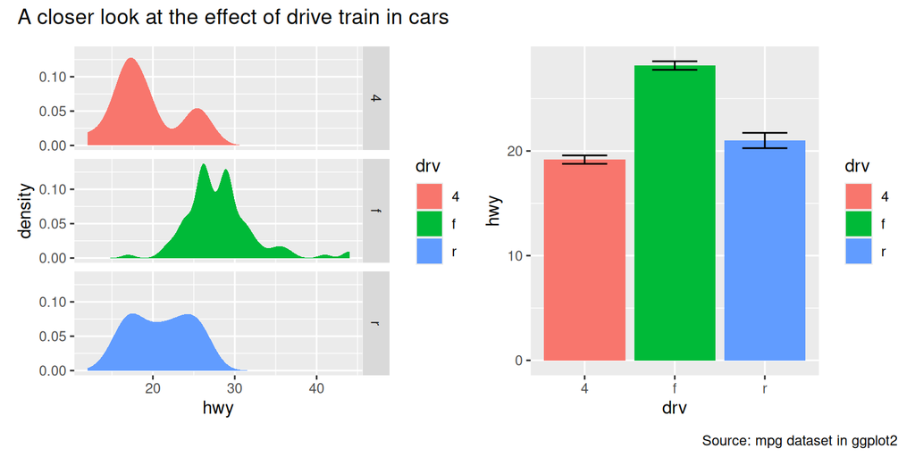

```r
p34 <- p3 + p4 + plot_annotation(
  title   = "A closer look at the effect of drive train in cars",
  caption = "Source: mpg dataset in ggplot2"
)
p34
```

**tidyplots**

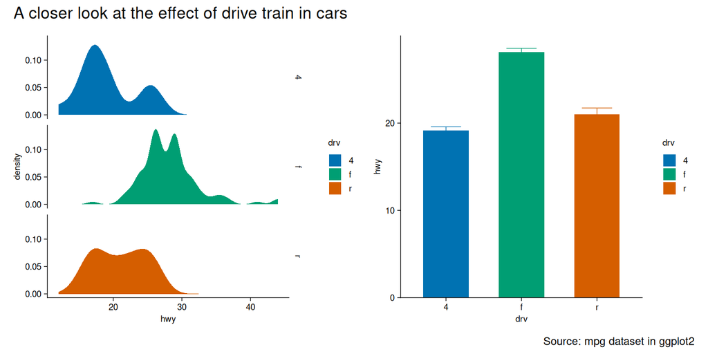

```r
t34 <- t3 + t4 + plot_annotation(
  title   = "A closer look at the effect of drive train in cars",
  caption = "Source: mpg dataset in ggplot2"
)
t34
```

### Auto-tagging panels

**ggplot2**

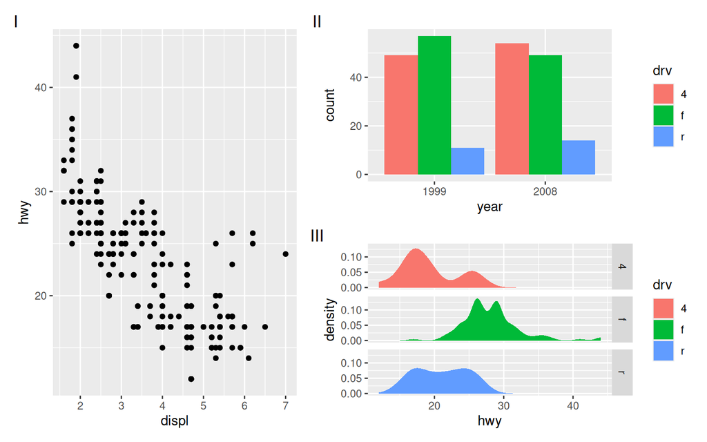

```r
p123 <- p1 | (p2 / p3)
p123 + plot_annotation(tag_levels = "I")
```

**tidyplots**

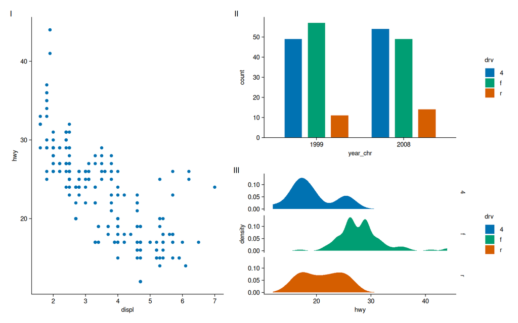

```r
t123 <- t1 | (t2 / t3)
t123 + plot_annotation(tag_levels = "I")
```

## 9.2 Arranging plots on top of each other

`inset_element()` overlays one plot on another. Coordinates are normalized to the host panel (0 to 1). This is also pure patchwork and works on tidyplots panels.

**ggplot2**

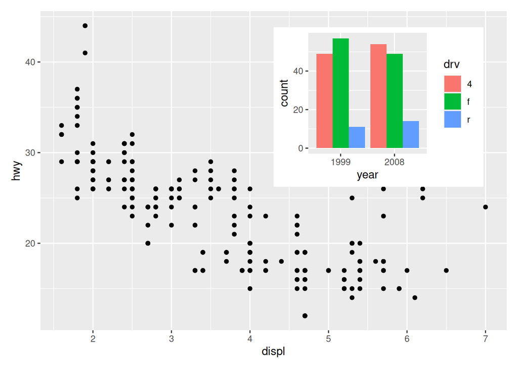

```r
p1 + inset_element(p2, left = 0.5, bottom = 0.45, right = 0.95, top = 0.95)
```

**tidyplots**

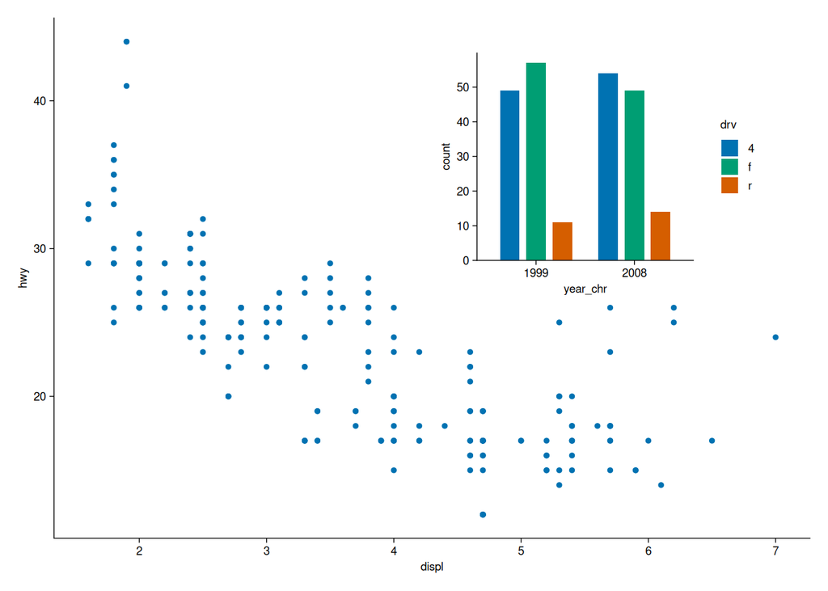

```r
t1 + inset_element(t2, left = 0.5, bottom = 0.45, right = 0.95, top = 0.95)
```

A patchwork object can itself be the inset, and the inset can be tagged like any other panel:

**ggplot2**

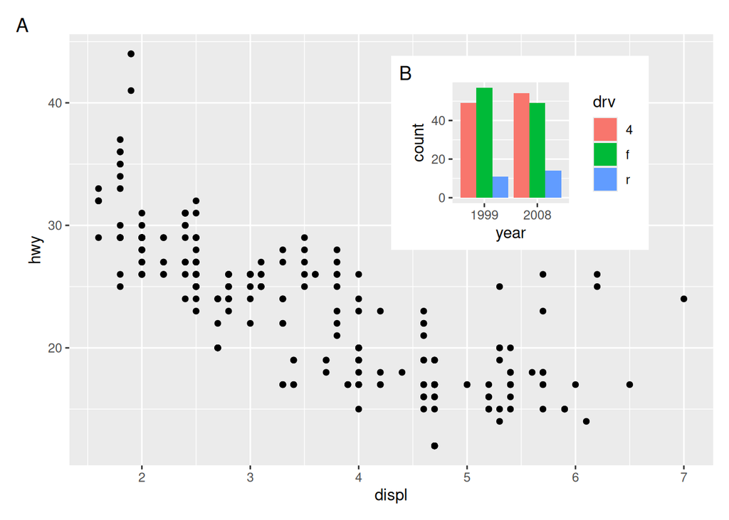

```r
p12_inset <- p1 + inset_element(p2, left = 0.5, bottom = 0.5, right = 0.9, top = 0.95)
p12_inset + plot_annotation(tag_levels = "A")
```

**tidyplots**

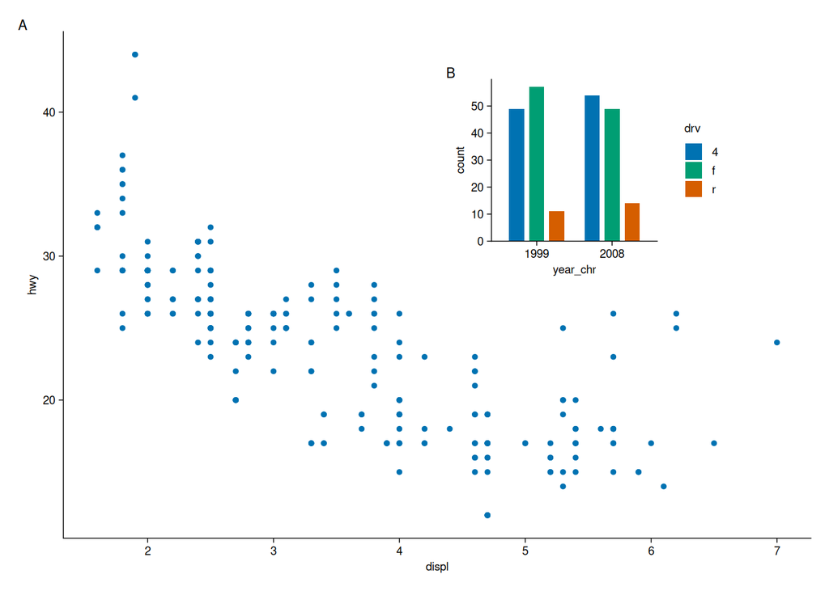

```r
t12_inset <- t1 + inset_element(t2, left = 0.5, bottom = 0.5, right = 0.9, top = 0.95)
t12_inset + plot_annotation(tag_levels = "A")
```

## 9.3 Wrapping up: split_plot is not patchwork

tidyplots’ one native multi-panel verb, `split_plot()`, splits a **single** plot into panels by a grouping variable. It is tidyplots’ answer to `facet_wrap()`, not to patchwork. Use it when one dataset should be broken out by a factor:

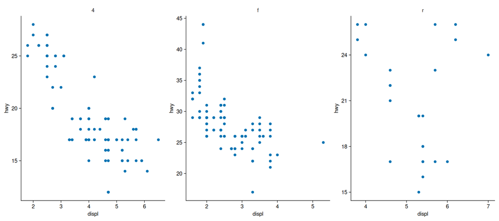

```r
mpg |>
  tidyplot(x = displ, y = hwy, width = NA, height = NA) |>
  add_data_points() |>
  split_plot(by = drv)        # one plot, three panels by drv (NOT a composition)
```

The distinction in one line:

- **`split_plot(by = v)`** takes one plot and one variable, makes one panel per level. It is faceting.
- **patchwork (`+`, `/`, `|`, `inset_element`)** takes several already-built, unrelated plots and arranges them. It is composition.

For everything in this chapter you want the second one, and tidyplots panels drop straight into it.